# Section Draft — Calibration

Draft of the paper’s calibration section, between the model and the scenarios: the dataset, what is taken from it directly, how the free parameters are set, the high-finance stress setting, the fit to 2011, and the eight baselines the scenarios are measured against. Supplementary Appendix 3 keeps the full parameter, initial-condition and convergence tables.

## Data

The model is built on EXIOBASE 3.8.2 for the observation year 2011; the 2018 date of the database citation is its release. Its 44 countries and five rest-of-world blocks are aggregated to two regions, and its 163 industries to 54 per region, through explicit concordances (Supplementary Appendix 2). The same table and pipeline give the two regional partitions of the Results: the EU and the Rest of the World, and North and South. The following are taken from the data without fitting:

- the inter-industry coefficients $A$, by supplying and using region;
- the capital-flow matrix $K$ (Södersten–Lenzen, EXIOBASE 2011): what each industry’s depreciation consists of, by product and by origin, so that $\mathbf 1^{\top}K = \mathbf d^{\top}$, the consumption of fixed capital per unit of output;
- the target capital–output ratios $\kappa_j = d_j/\delta_{s(j)}$, with $\delta_{s(j)}$ the Eurostat EU-27 2011 depreciation rate of the industry’s NACE section;
- labour productivity, employment and its female share;
- the final-demand share vectors, by channel and by origin;
- the emission, material, land and water intensities;
- the 2011 macroeconomic aggregates used as targets.

The price block is calibrated, not fitted. The money wage is anchored at its 2011 employment-weighted mean, and the enterprise premium $e$ in $r = r_b + e$ is the value at which the prices of production reproduce the observed 2011 price level.

## Stocks, the spin-up and stationarity

The input–output data give flows but no stocks, so every financial and real stock starts at zero. The model is run for 60 unshocked periods from 2011 flows, and every experiment restarts from the state that run reaches. Government-debt endowments, issued to each central bank at the start of the spin-up, set the level of public debt at which the economy is stationary; gold reserves start at a fixed endowment. Interventions begin at $t = 70$ of the main run.

## How the free parameters are set

The parameters the data do not give are set by searches over a small number of named instruments, each candidate run through the spin-up to $t = 100$. The instruments are the two government-debt endowments, the intercepts $\lambda^{E,0}$ of the equity shares of household wealth, and scale factors on the two income-tax rates. The targets, at $t = 100$, are government debt of 0.81 (EU) and 0.85 (RoW) of value added, a zero EU current account, firm loans of 0.83 (EU) and 0.81 (RoW) of value added, and the 2011 aggregates. Each search is a Newton iteration with a finite-difference Jacobian: one run at the current point and one per instrument moved alone, then the step $\theta - J^{-1}[y(\theta) - y^{\ast}]$, or a least-squares step when targets outnumber instruments. The debt endowment moves stationary debt one for one and leaves every flow unchanged to four digits, so its column of $J$ is known and enters linearly.

A point is accepted only if the baseline is stationary: debt/value added changes by less than $10^{-4}$ per period over $t = 76 \ldots 100$, debt and loans are within 0.03 of target, private and public capital within $10^{-4}$ of their targets, $|\text{CAB}/\text{VA}| < 5\times10^{-4}$, and no loan or equity stock is negative.

Acceptance of the EU/RoW high-finance baseline at t = 100.

| Region | Firm loans / VA | Government debt / VA | Debt/VA slope per period | CAB / VA | Capital / target − 1 |
| --- | --- | --- | --- | --- | --- |
| EU | 1.203 | 0.808 | 7.7e-05 | -1.5e-04 | -1.9e-05 |
| RoW | 0.818 | 0.833 | -6.4e-05 | 4.3e-05 | -8.6e-05 |

Coefficients with no 2011 counterpart are fixed by one-parameter scans, each with a criterion stated before its result: the Armington elasticity on intermediate inputs ($\varepsilon_{int} = 1.0$, the smallest value at which a depreciation improves the trade balance in every run), the portfolio scale ($\sigma = 4$ with adaptive expected returns, the largest value that passes the baseline acceptance tests in both setups), and the finance and credit coefficients. None of these has an empirical source.

## The high-finance stress setting

The Results run on a stress calibration. The EU firm-loan target is raised from 0.83 to 1.20 of value added; the finance coefficients (margin and leverage in the capital target, the liability premium) are five times their calibrated values, retention is 0.2, and the credit-rationing coefficients are raised to 0.5 and 1, so that the finance constraint and credit rationing have a balance sheet to act on. These are not estimates. At these values, the finance terms and their interaction with the scenarios account for 15.9% of the standardised variation of the scenario responses, against 3.2% on the calibrated capital arm.

## Fit to the 2011 targets

Model against the 2011 targets at t = 100 of the gold baselines. Full table: Supplementary Appendix 3.

| Setup | Concept | Z1 model / target | Z2 model / target |
| --- | --- | --- | --- |
| EU/RoW | Real consumption | 1.071 | 1.024 |
| EU/RoW | Real investment | 0.969 | 0.752 |
| EU/RoW | Real government spending | 1.002 | 1.000 |
| EU/RoW | Real final exports | 0.854 | 0.918 |
| EU/RoW | Real final imports | 0.918 | 0.854 |
| EU/RoW | Real gross output | 1.018 | 0.958 |
| EU/RoW | Value added | 1.004 | 1.001 |
| EU/RoW | Government debt / VA | 0.997 | 0.980 |
| North/South | Real consumption | 0.922 | 1.000 |
| North/South | Real investment | 1.026 | 0.445 |
| North/South | Real government spending | 1.000 | 1.000 |
| North/South | Real final exports | 0.720 | 0.771 |
| North/South | Real final imports | 0.771 | 0.720 |
| North/South | Real gross output | 0.952 | 0.843 |
| North/South | Value added | 1.023 | 0.861 |
| North/South | Government debt / VA | 1.000 | 1.015 |

The fit criterion, the sum of squared deviations from target in units of each region’s value added, is 0.00089 for EU/RoW and 0.00835 for North/South. The main misses are RoW investment (0.75 of target; the 2011 data include net investment, which a stationary baseline does not have), EU exports and RoW imports (0.85), and, in North/South, the South’s investment, value added and trade.

## The eight baselines

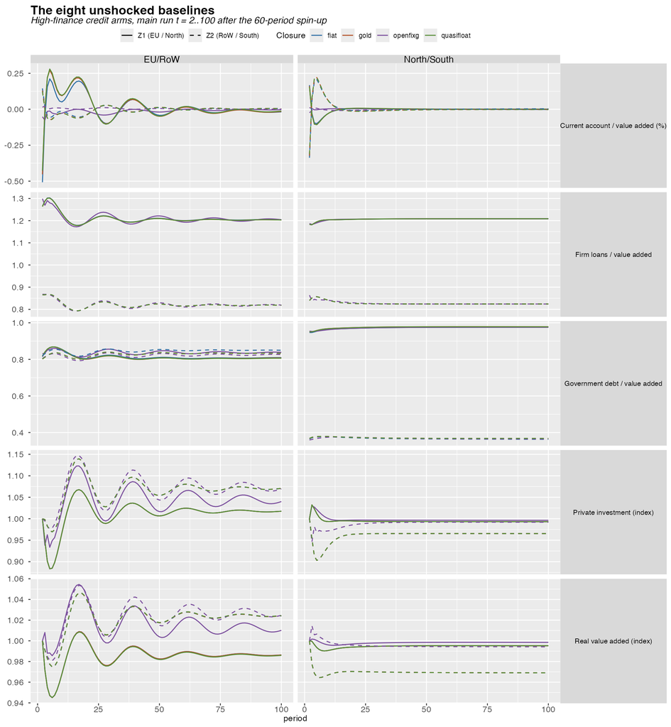

Figure 1: The eight unshocked baselines: two regional setups × four external closures, high-finance credit arms, t = 2..100 after the spin-up. Solid lines Z1, dashed Z2.

Every scenario is measured against the unshocked baseline of its own setup and closure. Two features of these baselines matter for reading the Results.

**EU/RoW returns to rest through a damped cycle; North/South does not.** EU value added in the EU/RoW gold baseline turns at $t$ = 17, 28, 39, 50, 61, 73, 83, 95, and each swing is 0.57–0.67 of the one before. The North/South baseline, with the same behavioural parameters, has 1 turning point(s) over the same window. The cycle comes from the firm accelerator and is analysed in the model section; it is why the Results average each response over one cycle, $t = 79 \ldots 100$.

**The closures share a path until they differ.** Gold, fiat and the quasi-float give almost the same baseline; OPENFIXG, in which the reserve-holding region’s government spending adjusts to its budget constraint, settles at a different level of activity and investment.